# Estudio variabilidad estructural proteica

30/01/2016

## Conjuntos de proteinas

### Conjunto teorico

190 mutantes de 2u2f (85 sitios) simuladas con el modelo mutacional MND con ANM *R0* = 12 y *Fmax* = 2 (solo para LFENM). Para determinar que sitios mutar, se alineo 2u2f con cada una de las proteinas del conjunto, se obtuvieron los indices de los sitios alineados pero mutados y se simularon 10 mutantes por cada par de proteinas, obteniendose un total de 190 mutantes. Luego, para el analisis, se tomaron como alineados los sitios alineados de 2u2f para cada par de proteinas.

### Conjunto experimental

19 proteinas de la familia de rrm. Las proteinas tienen un promedio de identidad secuencial de 22%. El core del alineamiento de la familia es de 57 sitios.

La caracterizacion del conjunto experimental se muestra a continuacion:

```
##     pdbid nsites naligned  identity       MSD
## 1   1nu4a     91       79 16.455696 26.052020
## 2   1a9nb     94       79 17.721519 27.523616
## 3  1fjeb2     84       71 18.309859  7.527169
## 4   1h6kx     77       73 24.657534 11.853500
## 5   1oo0b     92       78 29.487179  6.027857
## 6  1fxla1     85       77 27.272727  5.281823
## 7  1fxla2     82       77 33.766234  4.873353
## 8  1l3ka1     84       75 26.666667  6.679169
## 9   2msta     75       73 21.917808  9.444664
## 10  1hd1a     75       73 28.767123  6.888627
## 11 1fjeb1     91       72 11.111111 11.626778
## 12  1iqta     75       72 20.833333 15.339627
## 13 1cvja1     80       77 20.779221  6.546702
## 14 1cvja2     89       75 28.000000  3.653918
## 15   2u1a     88       74 24.324324  6.163450
## 16 1qm9a2    110       80 17.500000 18.192110
## 17 1qm9a1     88       75 18.666667 18.697912
## 18  1u2fa     90       76 23.684211  9.414722
## 19  1jmta     98       75  9.333333  8.278242
```

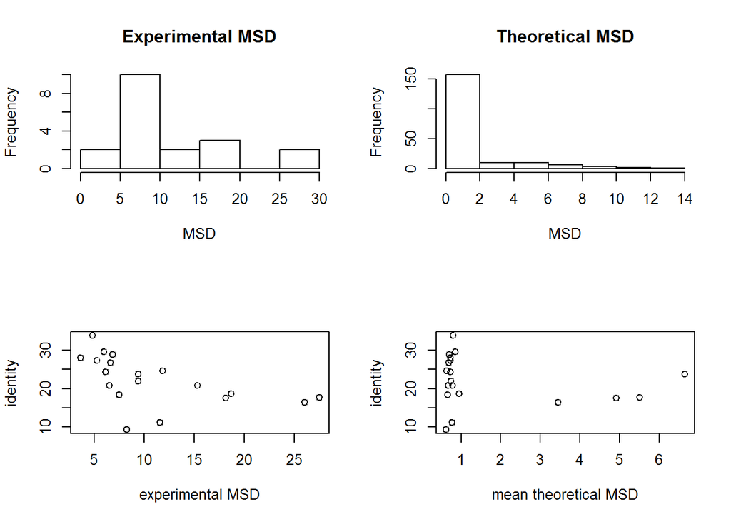

## Comparaciones

### RHO y AUC

Las distribuciones de *auc* y *rho* para cada conjunto se muestran a continuacion (azul= teorico, rojo = experimental)

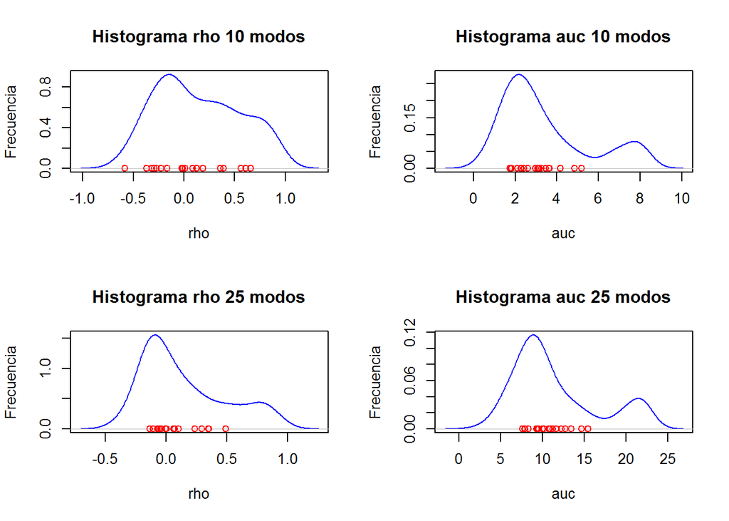

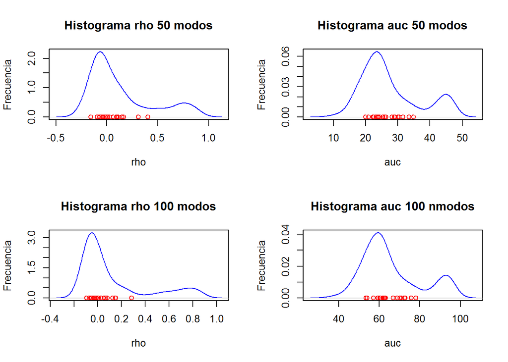

## Pn y Qn

Las distribuciones de *Pn* y *Qn* de los conjuntos son las siguientes:

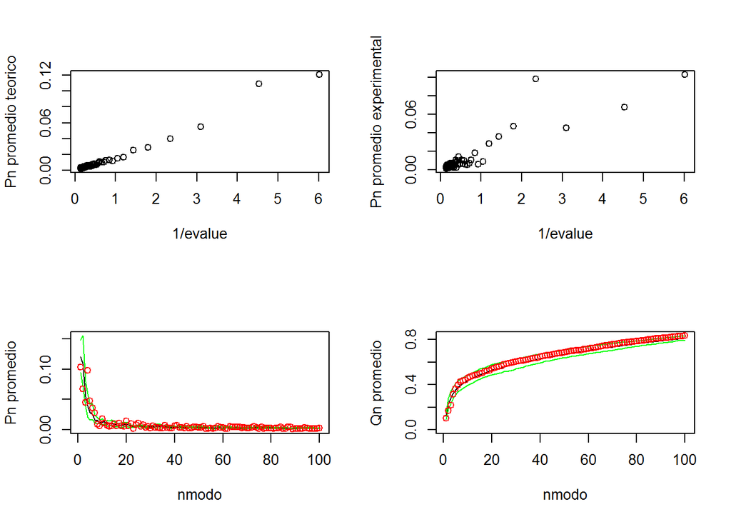

Negro: Teorico Rojo: Experimental Verdes: Cuartiles 0.05 y 0.95 de 10 grupos de 19 mutantes teoricas.